# Question

Ana y Diego viven en un aparta-estudio y comparten el pago de los gastos. Para saber cuál es el costo promedio del consumo diario, se resta del cobro total de ese mes el valor por servicio fijo, y luego se divide entre 30, que es el número de días que se utiliza para facturar un mes. En junio el cobro total fue de $22.618 y el valor por servicio fijo fue de $6.349. La gráfica muestra el consumo histórico en metros cúbicos de ese servicio.

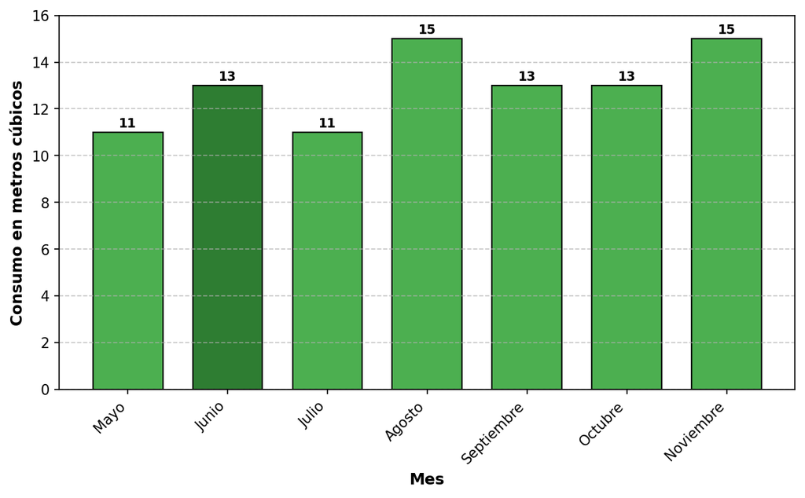

¿Cuál es el costo promedio aproximado, en pesos, del consumo diario de junio?

## Answerlist

- 542
- 754
- 525
- 212

# Solution

### Análisis del problema

Este problema requiere **interpretación de datos económicos** y **cálculo de costo promedio diario**. Los pasos son:

1. **Identificar los datos económicos** del enunciado
2. **Aplicar la fórmula de costo promedio diario** según las instrucciones
3. **Realizar el cálculo** correctamente

### Paso 1: Datos del problema

Según el enunciado, para junio:

- **Cobro total del mes:** $22.618
- **Valor por servicio fijo:** $6.349
- **Número de días para facturar:** 30 días

### Paso 2: Aplicación de la fórmula

Según las instrucciones del problema:

**Costo promedio diario = (Cobro total - Valor por servicio fijo) ÷ 30**

### Paso 3: Cálculo paso a paso

1. **Calcular el costo variable:** Costo variable = $22.618 - $6.349 = $16.269
2. **Calcular el costo promedio diario:** Costo promedio diario = $16.269 ÷ 30 = $542

### Verificación y análisis de distractores

**Respuesta correcta:** $542

**Análisis de errores conceptuales comunes:**

- **$754**: Error conceptual - no restar el valor por servicio fijo
- **$525**: Error de cálculo - dividir entre 31 días en lugar de 30
- **$212**: Error conceptual - usar solo el valor fijo dividido entre 30

### Conclusión

El costo promedio diario del consumo de junio es de **$542**.

Esta respuesta es coherente porque:

- Se basa en los datos económicos proporcionados en el enunciado
- Aplica correctamente la fórmula indicada: (Cobro total - Valor fijo) ÷ 30
- El resultado es razonable para un costo diario de consumo de gas natural

**Verificación del cálculo**: - Costo variable: $22.618 - $6.349 = $16.269 - Costo promedio diario: $16.269 ÷ 30 = $542

## Answerlist

- Correcto
- Incorrecto
- Incorrecto
- Incorrecto

# Meta-information

exname: Consumo Gas Natural Costo Promedio Diario extype: schoice exsolution: 1000 exshuffle: TRUE exsection: Aritmética|Cálculo de promedios|Análisis económico|Operaciones básicas exextra[Type]: Cálculo exextra[Program]: R exextra[Language]: es exextra[Level]: 2 exextra[Competencia]: Formulación y ejecución exextra[Componente]: Numérico variacional exextra[Contexto]: Familiar exextra[Dificultad]: Media